# レポート課題第10回

2class_data_nl2 .csv” に対してニューラルネットワークを用いて識別を行う。

学籍番号：2094572t  
氏名：木澤 祐人

# 準備

まず、Google Driveのマウントと作業フォルダへの移動を行う。

```python
from google.colab import drive
drive.mount('/content/drive')
# フォルダの移動には"%cd"を使用します。
# 作業フォルダへ移動
%cd /content/drive/'My Drive'/情報管理/10/
# 現在のフォルダの中身を表示
%ls
```

```
/content/drive/My Drive/情報管理/10
 10_01_softmax_3class.ipynb   3class_data.csv
 10_02_softmax_2class.ipynb   convert_report.ipynb
 10_03_neural_network.ipynb   report_10.ipynb
 2class_data.csv             'report_10.ipynb のコピー'
 2class_data_nl2.csv         'report_10.ipynb のコピー (1)'
 2class_data_nl.csv
```

次に、必要ライブラリをインポートする。

```python
import pandas as pd
import numpy as np
import matplotlib.pyplot as plt
```

続いて、`2class_data_nl2.csv` を読み込む。  
このデータはx1とx2の二次元データで、クラス0とクラス1の2クラスのどちらかに属している。

```python
# pandas の関数 read_csv を用いた csvファイル読み込み
csv_data = pd.read_csv('2class_data_nl2.csv', encoding='SHIFT-JIS')

# データの前半部(.headで取得できる)のみ表示
display(csv_data.head())

# x1とx2のデータを抽出し，numpy用データ(ndarray型) に変換する。
X = csv_data.loc[:, ['x1','x2']].to_numpy()

# クラス番号を抽出し，numpy用データ(ndarray型) に変換する。
Y = csv_data.loc[:,'class'].to_numpy()

# データのサンプル数と次元数を得る。
(num_samples, num_dimensions) = np.shape(X)
print('Nunber of samples: ' + str(num_samples))
print('Number of dimensions: ' + str(num_dimensions))

# クラス数を得る。
num_classes = int(np.max(Y) + 1)
print('Number of classes: ' + str(num_classes))
```

|  | class | x1 | x2 |
| --- | --- | --- | --- |
| 0 | 0 | 2.347 | 0.069 |
| 1 | 0 | 1.792 | 0.388 |
| 2 | 0 | 2.421 | -0.169 |
| 3 | 0 | 1.772 | -0.026 |
| 4 | 0 | 1.027 | 0.071 |

```
Nunber of samples: 600
Number of dimensions: 2
Number of classes: 2
```

標準化を行い、データをプロットする。

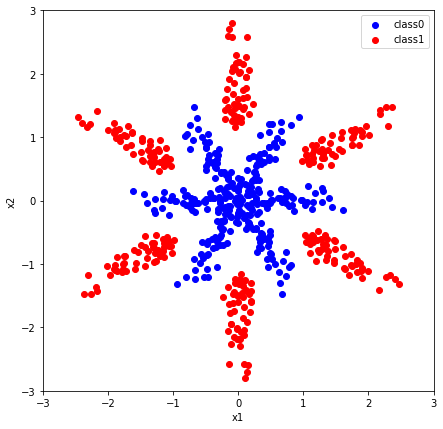

```python
# データを標準化する。
X = (X - np.mean(X, axis=0)) / np.std(X, axis=0)

# 以下は color_list = ['b', 'r'] とほぼ同じ。
# 光の三原色(赤,緑,青)の値それぞれを0～1の範囲で定義している。
color_list = [(0, 0, 1), (1, 0, 0)]

# データをプロット
plt.figure(figsize=(7,7))
for k in range(num_classes):
  # n番目のクラスに属している(Y==c)データをプロット
  plt.scatter(X[Y==k,0], X[Y==k,1], color=color_list[k], label='class'+str(k))
plt.xlabel('x1')
plt.ylabel('x2')
plt.legend()
plt.xlim([-3, 3])
plt.ylim([-3, 3])
plt.show()
```

このデータ`2class_data_nl2.csv`は**直線で2クラスに識別することはできない**。  
つまり、**線形分離不可能なデータ**ということになる。  
これをニューラルネットワークによって識別する。

# ニューラルネットワークの実装

ここでは、中間層の数を1、中間層のノードの数を6としたニューラルネットワークを実装する。  
このモデルの式は以下のようになる。

$\left[\begin{matrix}g_{1}\\g_{2}\\g_{3}\\g_{4}\\g_{5}\\g_{6} \end{matrix} \right] = \left[\begin{matrix} w_{11}^{\rm mid}x_1 + w_{12}^{\rm mid}x_2 + b_{1}^{\rm mid}\\ w_{21}^{\rm mid}x_1 + w_{22}^{\rm mid}x_2 + b_{2}^{\rm mid}\\ w_{31}^{\rm mid}x_1 + w_{32}^{\rm mid}x_2 + b_{3}^{\rm mid}\\ w_{41}^{\rm mid}x_1 + w_{42}^{\rm mid}x_2 + b_{4}^{\rm mid}\\ w_{51}^{\rm mid}x_1 + w_{52}^{\rm mid}x_2 + b_{5}^{\rm mid}\\ w_{61}^{\rm mid}x_1 + w_{62}^{\rm mid}x_2 + b_{6}^{\rm mid} \end{matrix} \right] = \left[\begin{matrix} w_{11}^{\rm mid} & w_{12}^{\rm mid} \\ w_{21}^{\rm mid} & w_{22}^{\rm mid} \\ w_{31}^{\rm mid} & w_{32}^{\rm mid} \\ w_{41}^{\rm mid} & w_{42}^{\rm mid} \\ w_{51}^{\rm mid} & w_{52}^{\rm mid} \\ w_{61}^{\rm mid} & w_{62}^{\rm mid} \end{matrix} \right] \left[\begin{matrix}x_1\\ x_2\end{matrix} \right] + \left[\begin{matrix}b_{1}^{\rm mid}\\b_{2}^{\rm mid}\\b_{3}^{\rm mid}\\b_{4}^{\rm mid}\\b_{5}^{\rm mid}\\b_{6}^{\rm mid} \end{matrix} \right] = {\bf W}^{\rm mid}{\bf x} + {\bf b}^{\rm mid}$

$\left[\begin{matrix}h_{1}\\h_{2} \\h_{3} \\h_{4} \\h_{5} \\h_{6} \end{matrix} \right] = \left[\begin{matrix}{\rm sigmoid}(g_1) \\ {\rm sigmoid}(g_2)\\ {\rm sigmoid}(g_3)\\ {\rm sigmoid}(g_4)\\ {\rm sigmoid}(g_5)\\ {\rm sigmoid}(g_6)\end{matrix} \right]$  
$\left[\begin{matrix}z_{1}\\z_{2} \end{matrix} \right] = \left[\begin{matrix} w_{11}h_1 + w_{12}h_2 + w_{13}h_3 + w_{14}h_4 + w_{15}h_5 + w_{16}h_6 + b_{1}\\ w_{21}h_1 + w_{22}h_2 + w_{23}h_3 + w_{24}h_4 + w_{25}h_5 + w_{26}h_6 + b_{2} \end{matrix} \right] = \left[\begin{matrix} w_{11} & w_{12} & w_{13} & w_{14} & w_{15} & w_{16}\\ w_{21} & w_{22} & w_{23} & w_{24} & w_{25} & w_{26} \end{matrix} \right]\left[\begin{matrix}h_1\\h_2\\h_3\\h_4\\h_5\\h_6 \end{matrix} \right] + \left[\begin{matrix}b_{1}\\ b_{2} \end{matrix} \right] = {\bf W}{\bf h} + {\bf b}$  
$\left[\begin{matrix}\hat{y}_{1}\\\hat{y}_{2} \end{matrix} \right] = \left[\begin{matrix}{\rm softmax}(z_1) \\ {\rm softmax}(z_2)\end{matrix} \right]$

${\bf W}^{\rm mod}$は中間層における重み行列で、サイズは ノード数 $\times$ 次元数 = $6 \times 2$である。  
${\bf b}^{\rm mod}$ は中間層における切片（バイアス）ベクトルで、サイズは ノード数$=6$ である。  
${\bf W}$は出力層における重み行列で、サイズは クラス数 $\times$ 中間層のノード数 = $2 \times 6$である。  
${\bf b}$ は出力層における切片（バイアス）ベクトルで、サイズは クラス数$=2$ である。

1サンプルデータに対してニューラルネットワークを通し、$\bf \hat{y}$ を計算する関数を以下に定義する。

```python
def sigmoid(z):
  '''
      シグモイド関数
  '''
  return (1+np.exp(-1*z))**(-1)

def softmax(z):
  '''
      ソフトマックス関数
      z: 要素数=クラス数のベクトル
      y_hat: クラス毎の確率。要素数=クラス数のベクトル
  '''
  return (np.exp(z) / np.sum(np.exp(z)))

def neural_network(x, w_mid_1, b_mid_1, w_mid_2, b_mid_2, w_mid_3, b_mid_3, w_mid_4, b_mid_4, w_mid_5, b_mid_5, w_mid_6, b_mid_6, W, b):
  '''
      1サンプルデータに対してニューラルネットワークによるクラス分類を行う
      x: 1サンプルデータ。サイズ=Dのベクトル
      w_mid_i: 中間層のノードiに関する重み行列。サイズ=Dのベクトル
      b_mid_i: 中間層のノードiに関するバイアス。スカラ
      W: 出力層の重み行列。サイズ=(KxJ)の行列
      b: 出力層のバイアス。サイズ=Kの行列
      ただし，D:次元数，J:中間層のノード数，K:クラス数である。
      y_hat: 出力層の出力。サイズ=Kのベクトル
      hi: 中間層のノードiの出力。スカラ
'''
  # 中間層を計算
  # ノード1を計算
  g1 = np.dot(w_mid_1, x) + b_mid_1
  h1 = sigmoid(g1)
  # ノード2を計算
  g2 = np.dot(w_mid_2, x) + b_mid_2
  h2 = sigmoid(g2)
  # ノード3を計算
  g3 = np.dot(w_mid_3, x) + b_mid_3
  h3 = sigmoid(g3)
  # ノード4を計算
  g4 = np.dot(w_mid_4, x) + b_mid_4
  h4 = sigmoid(g4)
  # ノード5を計算
  g5 = np.dot(w_mid_5, x) + b_mid_5
  h5 = sigmoid(g5)
  # ノード6を計算
  g6 = np.dot(w_mid_6, x) + b_mid_6
  h6 = sigmoid(g6)



  # 出力層を計算
  z = np.dot(W, np.array([h1, h2, h3, h4, h5, h6])) + b
  y_hat = softmax(z)

  return y_hat, h1, h2, h3, h4, h5, h6
```

各パラメータの初期値を決める。  
ロジスティック回帰のときと同様，${\bf b}^{\rm mod}$ および ${\bf b}$ の初期値はゼロ，${\bf W}^{\rm mod}$ および ${\bf W}$ の初期値は正規分布に従う乱数で決定する。

```python
np.random.seed(0)

# 中間層の初期値
# ノード1
initial_w_mid_1 =  np.random.randn(num_dimensions)
initial_b_mid_1 = 0
# ノード2
initial_w_mid_2 =  np.random.randn(num_dimensions)
initial_b_mid_2 = 0
# ノード3
initial_w_mid_3 =  np.random.randn(num_dimensions)
initial_b_mid_3 = 0
# ノード4
initial_w_mid_4 =  np.random.randn(num_dimensions)
initial_b_mid_4 = 0
# ノード5
initial_w_mid_5 =  np.random.randn(num_dimensions)
initial_b_mid_5 = 0
# ノード6
initial_w_mid_6 =  np.random.randn(num_dimensions)
initial_b_mid_6 = 0

# 出力層の初期値
initial_W =  np.random.randn(num_classes, 6) # ここの6はノード数の6に相当
initial_b = np.zeros(num_classes)

print('initial_w_mid_1 = ')
print(initial_w_mid_1)
print('initial_w_mid_2 = ')
print(initial_w_mid_2)
print('initial_w_mid_3 = ')
print(initial_w_mid_3)
print('initial_w_mid_4 = ')
print(initial_w_mid_4)
print('initial_w_mid_5 = ')
print(initial_w_mid_5)
print('initial_w_mid_6 = ')
print(initial_w_mid_6)
print('initial_W = ')
print(initial_W)
```

```
initial_w_mid_1 =
[1.76405235 0.40015721]
initial_w_mid_2 =
[0.97873798 2.2408932 ]
initial_w_mid_3 =
[ 1.86755799 -0.97727788]
initial_w_mid_4 =
[ 0.95008842 -0.15135721]
initial_w_mid_5 =
[-0.10321885  0.4105985 ]
initial_w_mid_6 =
[0.14404357 1.45427351]
initial_W =
[[ 0.76103773  0.12167502  0.44386323  0.33367433  1.49407907 -0.20515826]
 [ 0.3130677  -0.85409574 -2.55298982  0.6536186   0.8644362  -0.74216502]]
```

クロスエントロピー損失を計算する関数および勾配を計算する関数を定義する。  
勾配の計算式は以下のように定義される。  
$\frac{\partial L_{ce}}{\partial {\bf W}_{k}} = (\hat{y}_k - y_k){\bf h}$  
$\frac{\partial L_{ce}}{\partial {\bf b}_{k}} = \hat{y}_k - y_k$  
$\frac{\partial L_{ce}}{\partial {\bf W}_{j}^{\rm mod}} = \left [ \sum_{k=1}^{K}(\hat{y}_k - y_k)w_{kj} \right ] (1-h_j)h_j{\bf x}$  
$\frac{\partial L_{ce}}{\partial {\bf b}_{j}^{\rm mod}} = \left [ \sum_{k=1}^{K}(\hat{y}_k - y_k)w_{kj} \right ] (1-h_j)h_j$

$k$は出力層のノード番号（つまりクラス番号）、$j$は中間層のノード番号である。  
$y_k$は正解ラベルで、$k$が正解クラスの場合は確率1、不正解クラスの場合は0である。

```python
def cross_entropy(y_hat, y):
  '''
      クロスエントロピー損失を計算する。
      y_hat: マルチクラス回帰によって推定された y
      y: 正解のクラス
  '''
  # 正解クラスの確率を1，それ以外のクラスの確率を0とするベクトル（one-hotベクトル）を作成する。
  y_onehot = np.zeros(num_classes)
  y_onehot[y] = 1.0

  ce = -1.0 * np.sum(y_onehot*np.log(y_hat))

  return ce

def calc_gradient(y_hat, y, h1, h2, h3, h4, h5, h6, W, x):
  '''
      勾配を計算する
      y_hat: 出力層の出力: サイズ=Kのベクトル
      y: 正解のクラス番号: スカラ
      hi: 中間層のノードiの出力。スカラ
      W: 出力層の重み行列。サイズ=(KxJ)の行列
      x: データ: サイズ=Dのベクトル
      ただし，D:次元数，J:中間層のノード数，K:クラス数である。
      grad_w_mid_i: w_mid_iの勾配：サイズ=Dのベクトル
      grad_b_mid_i: b_mid_iの勾配：スカラ
      grad_W: Wの勾配: サイズ=(KxJ)の行列
      grad_b: bの勾配: サイズ=Kのベクトル
  '''
  # 次元数D, 中間層のノード数J, クラス数Kを得る。
  D = np.size(x)
  J = 6
  K = np.size(y_hat)

  # 正解クラスの確率を1，それ以外のクラスの確率を0とするベクトル（one-hotベクトル）を作成する。
  y_onehot = np.zeros(K)
  y_onehot[y] = 1.0

  # 出力層の勾配を計算
  grad_W = np.zeros([K, J])
  grad_b = np.zeros(K)
  for k in range(K):
    grad_W[k,:] = (y_hat[k] - y_onehot[k]) * np.array([h1, h2, h3, h4, h5, h6])
    grad_b[k] = y_hat[k] - y_onehot[k]

  # 中間層の勾配を計算
  # ノード1(W[:,0],h1を使っている点に注意)
  grad_w_mid_1 = np.sum((y_hat - y_onehot)*W[:,0])*(1 - h1)*h1 * x
  grad_b_mid_1 = np.sum((y_hat - y_onehot)*W[:,0])*(1 - h1)*h1
  # ノード2(W[:,1],h2を使っている点に注意)
  grad_w_mid_2 = np.sum((y_hat - y_onehot)*W[:,1])*(1 - h2)*h2 * x
  grad_b_mid_2 = np.sum((y_hat - y_onehot)*W[:,1])*(1 - h2)*h2
  # ノード3(W[:,2],h3を使っている点に注意)
  grad_w_mid_3 = np.sum((y_hat - y_onehot)*W[:,2])*(1 - h3)*h3 * x
  grad_b_mid_3 = np.sum((y_hat - y_onehot)*W[:,2])*(1 - h3)*h3
  # ノード4(W[:,3],h4を使っている点に注意)
  grad_w_mid_4 = np.sum((y_hat - y_onehot)*W[:,3])*(1 - h4)*h4 * x
  grad_b_mid_4 = np.sum((y_hat - y_onehot)*W[:,3])*(1 - h4)*h4
  # ノード5(W[:,4],h5を使っている点に注意)
  grad_w_mid_5 = np.sum((y_hat - y_onehot)*W[:,4])*(1 - h5)*h5 * x
  grad_b_mid_5 = np.sum((y_hat - y_onehot)*W[:,4])*(1 - h5)*h5
  # ノード6(W[:,5],h6を使っている点に注意)
  grad_w_mid_6 = np.sum((y_hat - y_onehot)*W[:,5])*(1 - h6)*h6 * x
  grad_b_mid_6 = np.sum((y_hat - y_onehot)*W[:,5])*(1 - h6)*h6


  return grad_w_mid_1, grad_b_mid_1, grad_w_mid_2, grad_b_mid_2, grad_w_mid_3, grad_b_mid_3, grad_w_mid_4, grad_b_mid_4, grad_w_mid_5, grad_b_mid_5, grad_w_mid_6, grad_b_mid_6, grad_W, grad_b
```

以上の関数を用いて、全てのデータを用いて繰り返し更新する。  
ここでは全データサンプルに対して更新を行うひとまとまりの処理を60エポック行う。

```python
from matplotlib import animation, rc
from IPython.display import HTML

np.random.seed(0)

# 学習率
lr = 0.2

# パラメータの初期化
w_mid_1 = initial_w_mid_1.copy()
b_mid_1 = initial_b_mid_1
w_mid_2 = initial_w_mid_2.copy()
b_mid_2 = initial_b_mid_2
w_mid_3 = initial_w_mid_3.copy()
b_mid_3 = initial_b_mid_3
w_mid_4 = initial_w_mid_4.copy()
b_mid_4 = initial_b_mid_4
w_mid_5 = initial_w_mid_5.copy()
b_mid_5 = initial_b_mid_5
w_mid_6 = initial_w_mid_6.copy()
b_mid_6 = initial_b_mid_6


W = initial_W.copy()
b = initial_b.copy()

# 描画
color_list = [(0, 0, 1), (1, 0, 0)]
fig = plt.figure(figsize=(7,7))
# データの描画
for k in range(num_classes):
  plt.scatter(X[Y==k,0], X[Y==k,1], color=color_list[k], label='class'+str(k))
images = []

# 損失関数の履歴
loss_history = np.array([])
# 正解率の履歴
acc_history = np.array([])

for epoch in range(60):

  # データをシャッフルしなおす。
  # (局所解に陥りにくくなるため)
  shuffle_index = np.random.permutation(np.arange(num_samples))
  X_tmp = X[(shuffle_index)]
  Y_tmp = Y[(shuffle_index)]

  loss = 0
  acc = 0
  for n in range(num_samples):
    x = X_tmp[n,:]
    y = Y_tmp[n]

    # ニューラルネットワークに与える
    y_hat, h1, h2, h3, h4, h5, h6 = neural_network(x, w_mid_1, b_mid_1, w_mid_2, b_mid_2, w_mid_3, b_mid_3, w_mid_4, b_mid_4, w_mid_5, b_mid_5, w_mid_6, b_mid_6, W, b)

    # 勾配の計算
    grad_w_mid_1, grad_b_mid_1, grad_w_mid_2, grad_b_mid_2, grad_w_mid_3, grad_b_mid_3, grad_w_mid_4, grad_b_mid_4, grad_w_mid_5, grad_b_mid_5, grad_w_mid_6, grad_b_mid_6, grad_W, grad_b = calc_gradient(y_hat, y, h1, h2, h3, h4, h5, h6, W, x)

    # 2エポック毎にアニメーション描画
    if n == 0 and epoch % 2 == 0:
      img = []
      x1 = np.linspace(-3, 3)

      x2 = -1.0 * (b_mid_1 + w_mid_1[0]*x1) / w_mid_1[1]
      img += plt.plot(x1, x2, color='k')
      x2 = -1.0 * (b_mid_2 + w_mid_2[0]*x1) / w_mid_2[1]
      img += plt.plot(x1, x2, color='k')
      x2 = -1.0 * (b_mid_3 + w_mid_3[0]*x1) / w_mid_3[1]
      img += plt.plot(x1, x2, color='k')
      x2 = -1.0 * (b_mid_4 + w_mid_4[0]*x1) / w_mid_4[1]
      img += plt.plot(x1, x2, color='k')
      x2 = -1.0 * (b_mid_5 + w_mid_5[0]*x1) / w_mid_5[1]
      img += plt.plot(x1, x2, color='k')
      x2 = -1.0 * (b_mid_6 + w_mid_6[0]*x1) / w_mid_6[1]
      img += plt.plot(x1, x2, color='k')


      img.append(plt.text(-2.8, 2.7, 'epoch: '+str(epoch), size='x-large'))
      images.append(img)

    # 更新
    W -= lr * grad_W
    b -= lr * grad_b
    w_mid_1 -= lr * grad_w_mid_1
    b_mid_1 -= lr * grad_b_mid_1
    w_mid_2 -= lr * grad_w_mid_2
    b_mid_2 -= lr * grad_b_mid_2
    w_mid_3 -= lr * grad_w_mid_3
    b_mid_3 -= lr * grad_b_mid_3
    w_mid_4 -= lr * grad_w_mid_4
    b_mid_4 -= lr * grad_b_mid_4
    w_mid_5 -= lr * grad_w_mid_5
    b_mid_5 -= lr * grad_b_mid_5
    w_mid_6 -= lr * grad_w_mid_6
    b_mid_6 -= lr * grad_b_mid_6


    # 損失関数の蓄積
    loss += cross_entropy(y_hat, y)
    # 正解率の蓄積
    if np.argmax(y_hat) == y:
      acc += 1

  loss /= num_samples
  acc /= num_samples
  loss_history = np.append(loss_history, loss)
  acc_history = np.append(acc_history, acc*100)
  print('%d-th epoch: cross entropy = %.3f, accuracy = %.3f%%' % (epoch+1, loss, acc*100))

plt.legend()
plt.xlim([-3, 3])
plt.ylim([-3, 3])

# アニメーション作成
anim = animation.ArtistAnimation(fig, images, interval=200)
# Google Colaboratoryの場合必要
rc('animation', html='jshtml')
plt.close()
display(anim)
```

```
1-th epoch: cross entropy = 0.610, accuracy = 66.500%
2-th epoch: cross entropy = 0.356, accuracy = 84.833%
3-th epoch: cross entropy = 0.284, accuracy = 88.833%
4-th epoch: cross entropy = 0.273, accuracy = 89.167%
5-th epoch: cross entropy = 0.267, accuracy = 89.333%
6-th epoch: cross entropy = 0.257, accuracy = 88.333%
7-th epoch: cross entropy = 0.239, accuracy = 89.167%
8-th epoch: cross entropy = 0.220, accuracy = 90.333%
9-th epoch: cross entropy = 0.202, accuracy = 92.667%
10-th epoch: cross entropy = 0.199, accuracy = 92.500%
11-th epoch: cross entropy = 0.188, accuracy = 92.500%
12-th epoch: cross entropy = 0.156, accuracy = 93.167%
13-th epoch: cross entropy = 0.161, accuracy = 92.333%
14-th epoch: cross entropy = 0.141, accuracy = 94.500%
15-th epoch: cross entropy = 0.128, accuracy = 95.833%
16-th epoch: cross entropy = 0.122, accuracy = 95.333%
17-th epoch: cross entropy = 0.101, accuracy = 96.833%
18-th epoch: cross entropy = 0.102, accuracy = 97.000%
19-th epoch: cross entropy = 0.089, accuracy = 96.667%
20-th epoch: cross entropy = 0.092, accuracy = 97.500%
21-th epoch: cross entropy = 0.078, accuracy = 97.833%
22-th epoch: cross entropy = 0.079, accuracy = 97.500%
23-th epoch: cross entropy = 0.070, accuracy = 98.000%
24-th epoch: cross entropy = 0.068, accuracy = 98.000%
25-th epoch: cross entropy = 0.060, accuracy = 98.333%
26-th epoch: cross entropy = 0.055, accuracy = 98.500%
27-th epoch: cross entropy = 0.062, accuracy = 98.333%
28-th epoch: cross entropy = 0.064, accuracy = 98.167%
29-th epoch: cross entropy = 0.059, accuracy = 98.333%
30-th epoch: cross entropy = 0.050, accuracy = 98.833%
31-th epoch: cross entropy = 0.060, accuracy = 98.000%
32-th epoch: cross entropy = 0.053, accuracy = 98.667%
33-th epoch: cross entropy = 0.050, accuracy = 98.667%
34-th epoch: cross entropy = 0.051, accuracy = 98.333%
35-th epoch: cross entropy = 0.049, accuracy = 98.500%
36-th epoch: cross entropy = 0.054, accuracy = 98.000%
37-th epoch: cross entropy = 0.057, accuracy = 98.167%
38-th epoch: cross entropy = 0.049, accuracy = 98.333%
39-th epoch: cross entropy = 0.048, accuracy = 98.500%
40-th epoch: cross entropy = 0.052, accuracy = 98.500%
41-th epoch: cross entropy = 0.047, accuracy = 98.167%
42-th epoch: cross entropy = 0.040, accuracy = 99.167%
43-th epoch: cross entropy = 0.048, accuracy = 97.833%
44-th epoch: cross entropy = 0.040, accuracy = 98.333%
45-th epoch: cross entropy = 0.038, accuracy = 98.667%
46-th epoch: cross entropy = 0.044, accuracy = 98.500%
47-th epoch: cross entropy = 0.040, accuracy = 98.333%
48-th epoch: cross entropy = 0.035, accuracy = 99.167%
49-th epoch: cross entropy = 0.024, accuracy = 99.333%
50-th epoch: cross entropy = 0.011, accuracy = 99.833%
51-th epoch: cross entropy = 0.008, accuracy = 100.000%
52-th epoch: cross entropy = 0.006, accuracy = 100.000%
53-th epoch: cross entropy = 0.005, accuracy = 100.000%
54-th epoch: cross entropy = 0.004, accuracy = 100.000%
55-th epoch: cross entropy = 0.004, accuracy = 100.000%
56-th epoch: cross entropy = 0.004, accuracy = 100.000%
57-th epoch: cross entropy = 0.004, accuracy = 100.000%
58-th epoch: cross entropy = 0.003, accuracy = 100.000%
59-th epoch: cross entropy = 0.003, accuracy = 100.000%
60-th epoch: cross entropy = 0.003, accuracy = 100.000%
```

[figure not shown]

上記のアニメ－ションでは，中間層の6個のノードそれぞれに関する直線をプロットしている。

エポック毎の損失関数および分類正解率をプロットする。

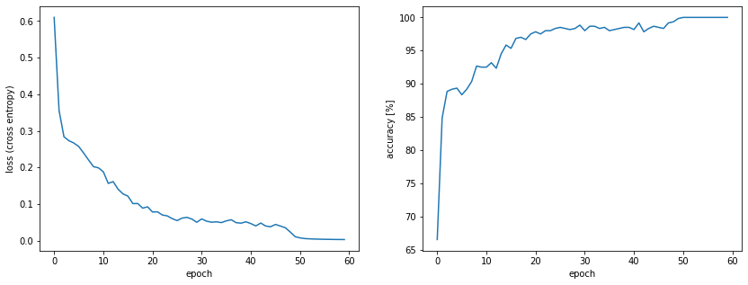

```python
plt.figure(figsize=(14,5))
plt.subplot(1,2,1)
plt.plot(loss_history)
plt.xlabel('epoch')
plt.ylabel('loss (cross entropy)')
plt.subplot(1,2,2)
plt.plot(acc_history)
plt.xlabel('epoch')
plt.ylabel('accuracy [%]')
plt.show()
```

学習完了後の分類正解率を計算する。

```python
# 正解率
accuracy = 0

for n in range(num_samples):
  x = X[n,:]
  y = Y[n]
  # ニューラルネットワークに与える
  y_hat, h1, h2, h3, h4, h5, h6 = neural_network(x, w_mid_1, b_mid_1, w_mid_2, b_mid_2, w_mid_3, b_mid_3, w_mid_4, b_mid_4, w_mid_5, b_mid_5, w_mid_6, b_mid_6, W, b)

  if np.argmax(y_hat) == y:
    accuracy += 1

accuracy = 100.0 * accuracy / num_samples

print('Accuracy = %.3f' % (accuracy))
```

```
Accuracy = 100.000
```

100%の正解率が得られた。

最後に、識別境界を可視化する。  
今回、中間層には6個のノードを設定しているので、中間層においては6本の直線が学習されていることになる。  
ここでは、識別境界に加えて、中間層で学習された6本の直線もプロットする。

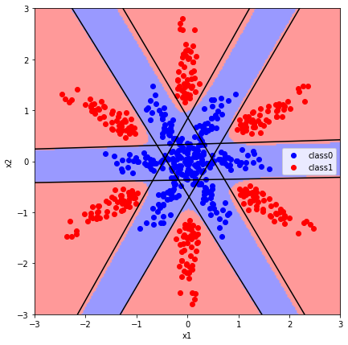

```python
# x1，x2ごとの格子点の数
grid_size = 200

# 格子点：-3.1から3.1まで200個分，等間隔に区切った数列
grid = np.linspace(-3.1, 3.1, grid_size)

# クラス識別結果を色塗りする領域：200x200の図
# 最後の3は，色情報(RGB=赤・緑・青の3次元ごとの色の強さ)
image = np.zeros([grid_size, grid_size, 3])

color_list = [(0, 0, 1), (1, 0, 0)]

for i in range(grid_size):
  for j in range(grid_size):
    # 格子点のデータ
    x = np.array([grid[j], grid[i]])
    # 格子点データを識別する
    y_hat, h1, h2, h3, h4, h5, h6 = neural_network(x, w_mid_1, b_mid_1, w_mid_2, b_mid_2, w_mid_3, b_mid_3, w_mid_4, b_mid_4, w_mid_5, b_mid_5, w_mid_6, b_mid_6, W, b)
    label = np.argmax(y_hat)
    # 識別結果のクラスの色で，色を塗る
    # (グラフは原点が左下だが，画像は左上が原点なので，上下反転させるために-iとしている)
    image[-i, j, :] = color_list[label]

plt.figure(figsize=(7,7))
# 色塗り結果を表示
plt.imshow(image, alpha=0.4, extent=(-3.1, 3.1, -3.1, 3.1))
# データおよび中間層の識別補助線を表示
x1 = np.linspace(-3, 3)
x2 = -1.0 * (b_mid_1 + w_mid_1[0]*x1) / w_mid_1[1]
plt.plot(x1, x2, color='k')
x2 = -1.0 * (b_mid_2 + w_mid_2[0]*x1) / w_mid_2[1]
plt.plot(x1, x2, color='k')
x2 = -1.0 * (b_mid_3 + w_mid_3[0]*x1) / w_mid_3[1]
plt.plot(x1, x2, color='k')
x2 = -1.0 * (b_mid_4 + w_mid_4[0]*x1) / w_mid_4[1]
plt.plot(x1, x2, color='k')
x2 = -1.0 * (b_mid_5 + w_mid_5[0]*x1) / w_mid_5[1]
plt.plot(x1, x2, color='k')
x2 = -1.0 * (b_mid_6 + w_mid_6[0]*x1) / w_mid_6[1]
plt.plot(x1, x2, color='k')


for k in range(num_classes):
  plt.scatter(X[Y==k,0], X[Y==k,1], color=color_list[k], label='class'+str(k))
plt.legend()
plt.xlabel('x1')
plt.ylabel('x2')
plt.xlim([-3, 3])
plt.ylim([-3, 3])
plt.show()
```

中間層の6本の直線によって、非線形な識別境界が作られていることが分かる。  
この例では、それぞれ平行に近い3組の直線のうち、  
いずれかの組にはさまれたデータはクラス0（青）  
それ以外はクラス1(赤)  
として識別されている。